# Model Performance

Hakan Egeli

Soumyendu Sarkar

May 8, 2018

# Model After Backward Elimitaion Process

## Classification Models

To improve our initial Naive model we have built several more models for our classification problem using:

- Decision Tree (**rpart** and **raprt2**),
- Linear Discriminant Analysis with Stepwise Feature Selection (**stepLDA**),
- Neural Networks Using Model Averaging (**avNNet**),
- Multinomial Regression Model via Neural Networks (**multinom**),
- Random Forest (**rf**),
- Single-hidden-layer Neural Network (**nnet**),
- Support Vector Machines with Linear Kernel (**svmLinear**)
- Support Vector Machines with Radial Basis Function Kernel (**svmRad**)
- Support Vector Machines with Polynomial Kernel (**svmPoly**)

and we have performed a repeated K-fold cross-validation totaling 10 folds for each model.

```
##            Accuracy AccuracySD      Kappa    KappaSD
## rf        0.9203177 0.01204365 0.89013985 0.01641079
## multi     0.8669827 0.01200565 0.81481833 0.01641801
## rpart2    0.8464301 0.01558529 0.78256002 0.02153364
## svmPoly   0.8111364 0.03577376 0.73954355 0.04860663
## avNNet    0.7959237 0.07862285 0.69938719 0.12583632
## rpart     0.7938005 0.02814153 0.70422098 0.04271963
## svmRad    0.7912397 0.01970821 0.71851078 0.02664128
## steplda   0.7750468 0.01823475 0.67410670 0.02701206
## svmLinear 0.6953553 0.03842007 0.58783471 0.05324479
## nnet      0.6835621 0.26227119 0.52736918 0.40836479
## naive     0.3734667 0.00769407 0.03744545 0.03515169
```

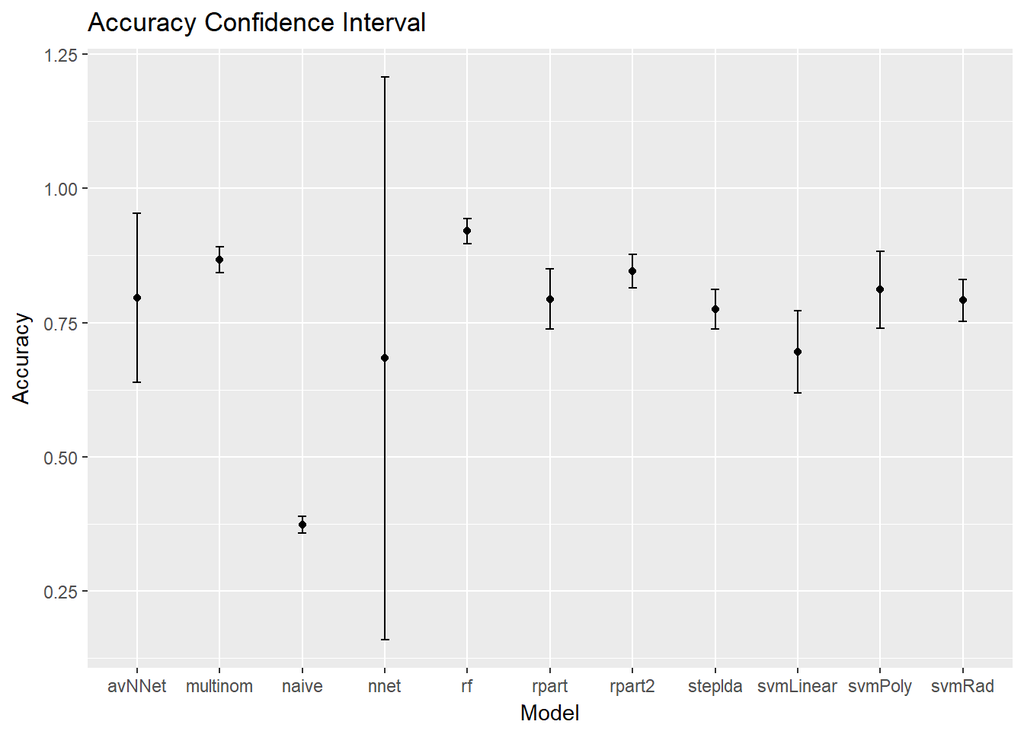

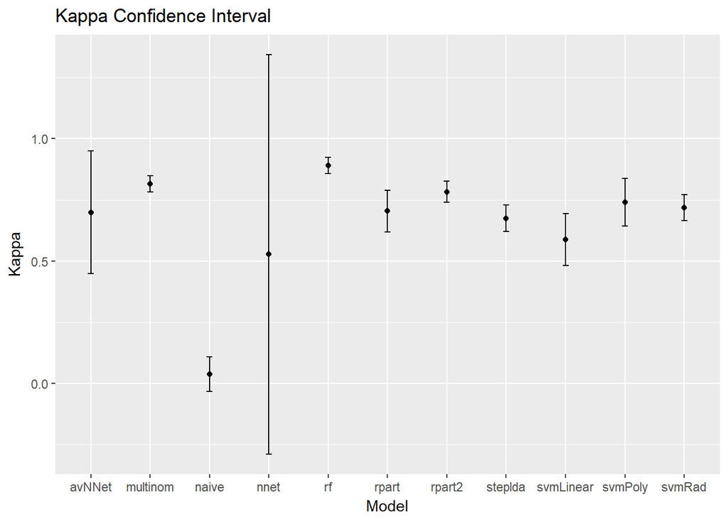

We looked at the Accuracy and Kappa model performance metrics and the confidence interval for each model and determined that the Random Forest model and the Multinomial Regression model were the top two performers. Then, we cheched the performance metics for these two top models against the test dataset that we have set aside (which as not used during the training) to re-evaluate their performance.

## Classification Test Accuracy for the Top Two Models

Random Rorest model against the test data:

```r
predictions <- predict(model_rf, newdata=dataset_test)
cm <- confusionMatrix(dataset_test$CreditLimitCategory, predictions)
cm$overall
```

```
##       Accuracy          Kappa  AccuracyLower  AccuracyUpper   AccuracyNull
##   9.362319e-01   9.118794e-01   9.050434e-01   9.596089e-01   3.652174e-01
## AccuracyPValue  McnemarPValue
##  7.300791e-112            NaN
```

```
##              Sensitivity Specificity Precision    Recall
## Class: X0      1.0000000   1.0000000 1.0000000 1.0000000
## Class: X1000   0.8859649   0.9913420 0.9805825 0.8859649
## Class: X2000   0.7727273   0.9752322 0.6800000 0.7727273
## Class: X3000   0.9310345   0.9721254 0.8709677 0.9310345
## Class: X5000   1.0000000   0.9817352 0.9692308 1.0000000
```

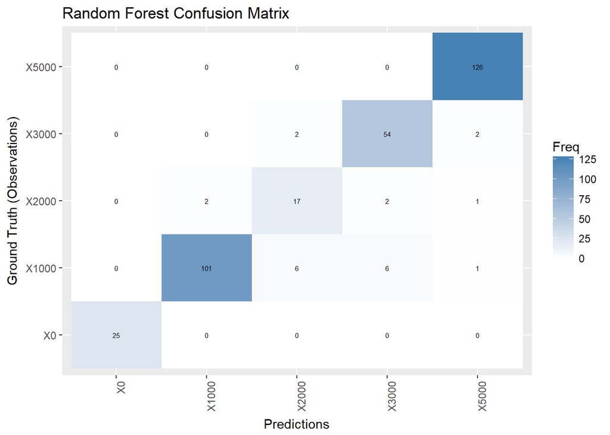

Multinomial Regression model against the test data:

```r
predictions <- predict(model_nnet, newdata=dataset_test)
cm <- confusionMatrix(dataset_test$CreditLimitCategory, predictions)
cm$overall
```

```
##       Accuracy          Kappa  AccuracyLower  AccuracyUpper   AccuracyNull
##   8.202899e-01   7.504375e-01   7.756276e-01   8.593522e-01   3.681159e-01
## AccuracyPValue  McnemarPValue
##   1.523807e-66            NaN
```

```
##              Sensitivity Specificity Precision    Recall
## Class: X0      0.8695652   0.9844720 0.8000000 0.8695652
## Class: X1000   0.7818182   0.9276596 0.8349515 0.7818182
## Class: X2000   0.2000000   0.9313433 0.0800000 0.2000000
## Class: X3000   0.6933333   0.9629630 0.8387097 0.6933333
## Class: X5000   0.9685039   0.9678899 0.9461538 0.9685039
```

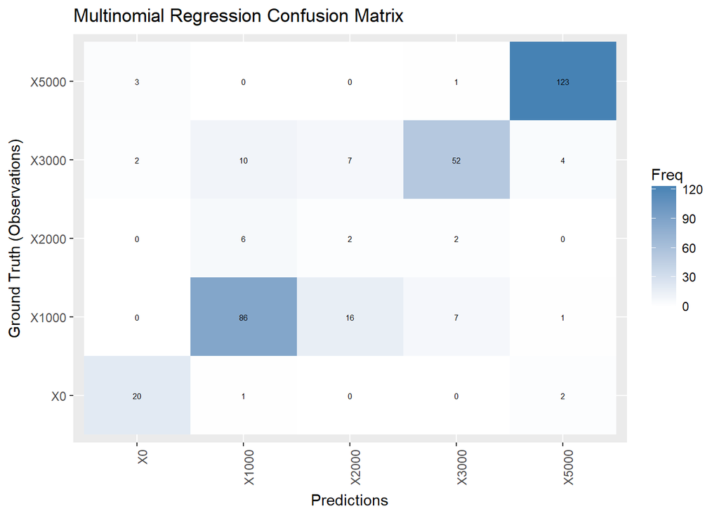

## Final Model

From the last two model tests, we have confirmed that the model built using the random forest was the one with the best accuracy and the best Kappa performance metrics.

We re-trainned the Random Forest model using the entire dataset in order to save this model and package it.

```r
model_rf <- train(CreditLimitCategory ~ JBTRating + CreditLimitLocked + SalesCurrentYr + SalesLastYr + DesignBandSalesLast12Mo + NumberOfStoreLocations + AvgDaysOfPayCategory + ReturnedPaymentCount + RuralUrbanContinuumCode + MetroIndicator + MedianEarnings + MedianIncomeHouseholds - 1, data=dataset, method="rf", metric="Accuracy", trControl=control, tuneGrid=data.frame(.mtry=19))
```

Final Accuracy and Kappa values and Standard Deviations

```
##   mtry  Accuracy     Kappa AccuracySD    KappaSD
## 1   19 0.9231952 0.8941259 0.01295398 0.01752243
```